# EDA

### Acid exploration

Using multivariate plots we should be able to investigate further the relationship between the acids and quality.

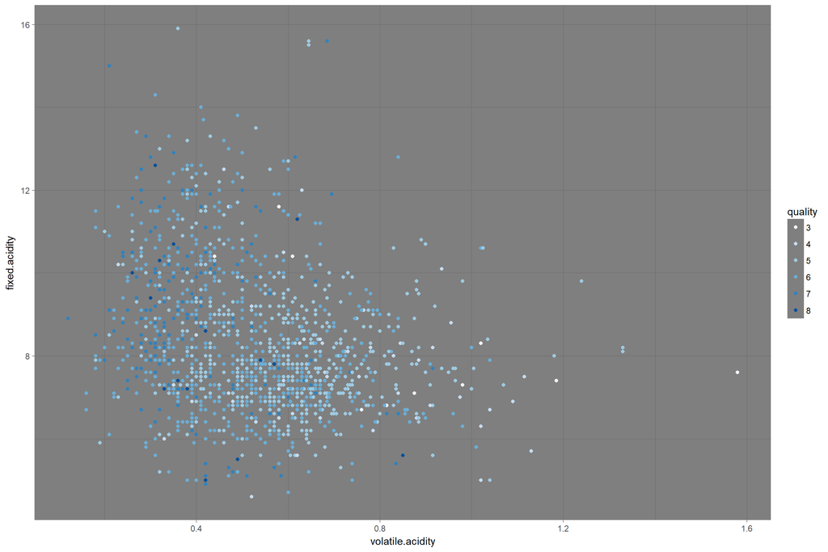

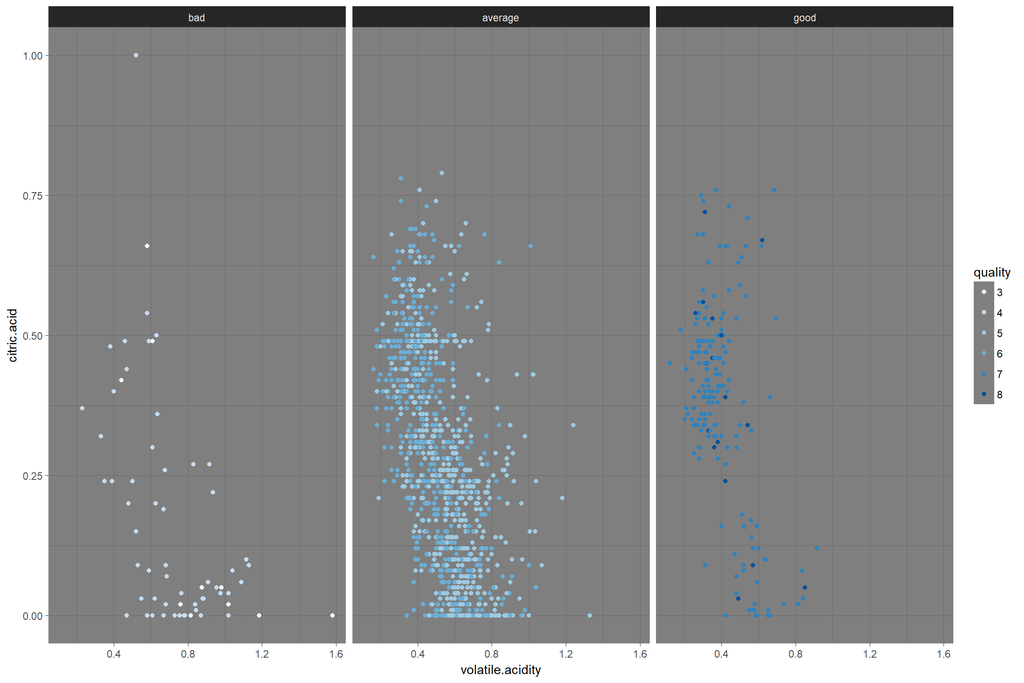

High citric acid and low acetic acid seems like a good combination.

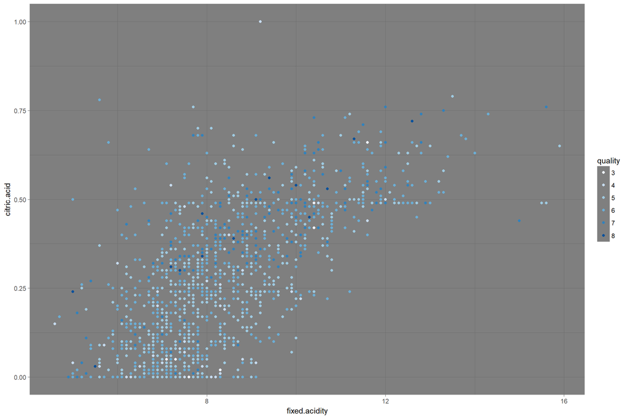

```
##
##  Pearson's product-moment correlation
##
## data:  wine$citric.acid and wine$fixed.acidity
## t = 36.234, df = 1597, p-value < 2.2e-16
## alternative hypothesis: true correlation is not equal to 0
## 95 percent confidence interval:
##  0.6438839 0.6977493
## sample estimates:
##       cor
## 0.6717034
```

Altough there seems to a correlation between tartaric acid and citric acid concentrations, nothing stands out in terms of quality.

# Multivariate Analysis

### Talk about some of the relationships you observed in this part of the investigation. Were there features that strengthened each other in terms of looking at your feature(s) of interest?

High alcohol contents and high sulphate concentrations combined seem to produce better wines.

# Final Plots and Summary

### Plot 1

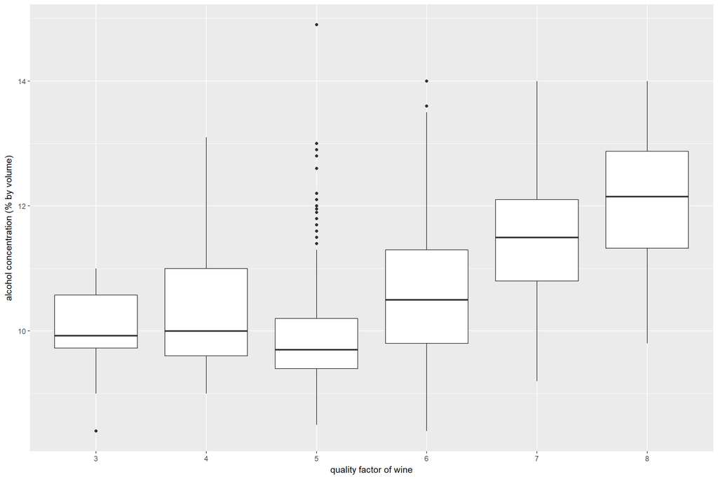

[output not shown]

Description: Alcohol has a big influence on wine. So its an important factor to look for the next time you go alcohol shopping as higher the amount of alcohol stronger is the wine.

### Plot 2

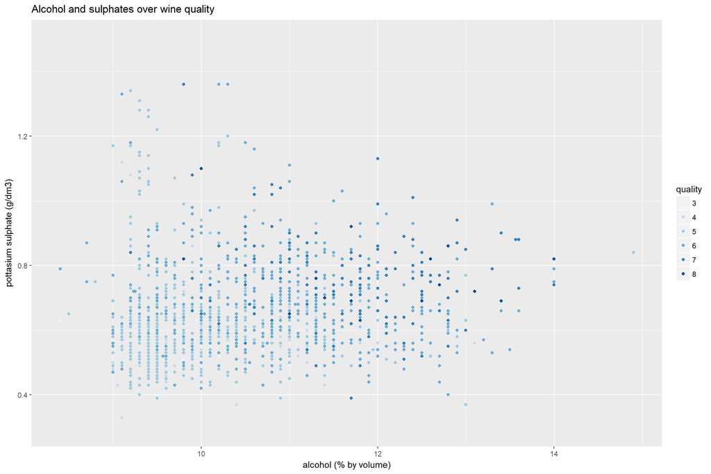

Description: High alcohol contents and high sulphate concentrations combined seem to produce better wines.

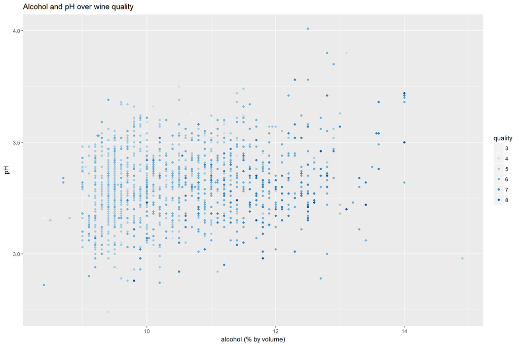

# Reflection

The wine data set contains information on the chemical properties of a selection of wines collected. It also includes wine ranking. A rating variable was created to determine the quality of wine. Depending on quality the wine is divided into good average or bad. The first thing I noticed was the high concentration of wines in the middle ranges of the ranking, that is, average tasting wines.Out of the chemical varibles, the only one that stood out was the concentration of citric acid (variable name citric.acid). First thing i noticed was the high number of wines that had no citric.acid at all.Nonetheless this variable also showed a strange distribution with some peaks but showing an almost rectangular distribution specially in the 0-0.5 range. All of the other variables showed either an normal or long tailed looking distribution. After exploring the individual variables, I proceded to investigate the relationships between each input variable and the outcome variable quality. The most promissing varibles were alcohol concentration, sulphates and the individual acid concentrations. I also tried investigating the effect of each acid in the overall pH for the wine. I used scatterplots to explore the relationships graphically and also generated a linear model to check how much of pH the three variables accounted for. The first surprise here was finding that the correlation between acetic acid concentration and pH was positive. I immediately suspected this was the result of some lurking variable Simpsons paradox. The second finding was discovering that the concentration of the three acids only account for less than half of the variance in pH. I interpreted this as a sign that there more components affecting acidity that were not measured. On the final part of the analysis I tried using multivariate plots to investigate if there were interesting combinations of variables that might affect quality. I also used a multivariate plot to confirm that density did not have an effect on quality when holding alcohol concentration constant. I think it would be interesting to include each wine critic judgement as separate entry in the dataset. After all, each individual has a different taste and is subject to prejudice and other distorting factors. I believe that having this extra information would add more value to the analysis.